# Zależność pomiędzy dwoma zmiennymi jakościowymi

pogRomcy danych

sezon 3 / odcinek 3  
Wszelkie prawa zastrzeżone.  
Wykorzystanie możliwe wyłącznie za zgodą autora.  
Naciśnij `A` by zamienić slajdy na ciągły tekst.  
Naciśnij `T` by wyświetlić spis treści.

# O czym jest ten odcinek

W poprzednim odcinku pokazaliśmy jak badać zależność pomiędzy dwoma zmiennymi binarnymi.

A co w sytuacji gdy zmienne nie są binarne? Temu tematowi poświęcony jest ten odcinek.

W tym odcinku nauczymy się jak:

- jak budować i jak czytać tablice kontyngencji dla pary zmiennych jakościowych
- jak przedstawiać graficznie tabelę kontyngencji
- jak statystycznie testować zależność pomiędzy parą zmiennych.

Do ilustracji tych zagadnień wykorzystamy dwa zbiory danych. Pierwszy, to dane z Diagnozy Społecznej, dostępne w tabeli `diagnoza` a drugi o nowotworze piersi, dostępne w tabeli `TCGA_BRCA`, oba dostępne w pakiecie `PogromcyDanych`.

# Wczytanie danych

Dane od których rozpoczniemy przykłady to `diagnoza` z pakietu `PogromcyDanych`. Aby te dane wczytać, wystarczy włączyć ten pakiet - instrukcja jak to zrobić znajduje się w odcinku 2 pierwszego sezonu.

W zbiorze danych `diagnoza` dostępnych jest kilkadziesiąt kolumn, opisujących odpowiedzi na różne interesujące pytania. W tym odcinku przyjrzymy się tylko kilku wybranym kolumnom, opisującym imię, wiek, płeć, ukończoną edukację oraz odpowiedź na pytanie ,,Co jest według Pana ważniejsze w życiu?’’ (zmienna w kolumnie `gp29`) z możliwymi odpowiedziami *Poczucie sensu* i *Przyjemności*.

```r
library(PogromcyDanych)
diagnoza[1:6, c("imie_2011", "wiek2013", "plec", "eduk4_2013", "gp29")]
```

```
##   imie_2011 wiek2013      plec                    eduk4_2013
## 1  WERONIKA        4   kobieta                          <NA>
## 2    ERNEST       13 mężczyzna zasadnicze zawodowe/gimanzjum
## 3    SYLWIA       23   kobieta           wyższe i policealne
## 4   MARIOLA       27   kobieta           wyższe i policealne
## 5    WACŁAW       78 mężczyzna           podstawowe i niższe
## 6     PIOTR       48 mężczyzna zasadnicze zawodowe/gimanzjum
##             gp29
## 1           <NA>
## 2 POCZUCIE SENSU
## 3   PRZYJEMNOSCI
## 4 POCZUCIE SENSU
## 5 POCZUCIE SENSU
## 6 POCZUCIE SENSU
```

# Jak wygląda tabela kontyngencji dla wykształcenia

W poprzednim odcinku przyglądaliśmy się parze zmiennych `plec`, czyli płeć respondenta i `gp29`, czyli odpowiedź na pytanie co jest ważniejsze w życiu.

W tym odcinku przyjrzymy się zależności pomiędzy poziomem edukacji (zmienna `eduk4_2013`) a odpowiedziami na pytanie o to co jest ważniejsze w życiu.

Zobaczmy jak wygląda tablica kontyngencji, zestawiająca te dwie zmienne.

```r
table(diagnoza$eduk4_2013, diagnoza$gp29)
```

```
##
##                                 PRZYJEMNOSCI POCZUCIE SENSU
##   BD/ND/FALA                               0              0
##   podstawowe i niższe                   1872           2898
##   zasadnicze zawodowe/gimanzjum         3662           4885
##   średnie                               2983           4770
##   wyższe i policealne                   1707           3370
```

Zmienna `eduk4_2013` poza czterema poziomami edukacji ma też piąty poziom `BD/ND/FALA`, który w tych danych nie występuje. Najłatwiej go usunąć funkcją `droplevels()`.

```r
(edukacjaTab <- table(droplevels(diagnoza$eduk4_2013), diagnoza$gp29))
```

```
##
##                                 PRZYJEMNOSCI POCZUCIE SENSU
##   podstawowe i niższe                   1872           2898
##   zasadnicze zawodowe/gimanzjum         3662           4885
##   średnie                               2983           4770
##   wyższe i policealne                   1707           3370
```

W każdej grupie wykształcenia respondenci częściej deklarują, że ważniejsze jest poczucie sensu. Ale czy są różnice pomiędzy grupami wykształcenia są duże?

# Jak wygląda tabela kontyngencji dla wieku

Zobaczmy jak wygląda zależość pomiędzy wiekiem a odpowiedziami na pytanie o sens w życiu.

Wiek jest zmienną ciągłą, zamienimy więc ją na zmienną jakościową o czterech poziomach. Aby zdyskretyzować zmienną ciągłą na dyskretną wykorzystamy funkcję `cut()` w której za granice przedziałów wiekowych wybierzemy 0, 25, 40, 60 i 110 lat.

```r
diagnoza$wiek2013_4g <- cut(diagnoza$wiek2013, c(0, 25, 40, 60, 110))
table(diagnoza$wiek2013_4g)
```

```
##
##   (0,25]  (25,40]  (40,60] (60,110]
##    11049     7770    10414     9051
```

Przedstawmy teraz jak wygląda zależność pomiędzy wiekiem a odpowiedziami na pytani o to co jest ważneijsze w życiu?

```r
(wiekTab <- table(diagnoza$wiek2013_4g, diagnoza$gp29))
```

```
##
##            PRZYJEMNOSCI POCZUCIE SENSU
##   (0,25]           1816           1887
##   (25,40]          2378           3296
##   (40,60]          3429           5673
##   (60,110]         2629           5098
```

# Więcek kolumn / wierszy

Strona 25 z http://diagnoza.com/pliki/kwestionariusze_instrukcje/kwestionariusze_2013.pdf Pytanie 54

```r
table(diagnoza$gp54_13, diagnoza$wiek2013_4)
```

```
##
##                    (0,25] (25,40] (40,60] (60,110]
##   ZDECYDOWANIE TAK    333     398     612      505
##   TAK                 665    1147    2156     1927
##   RACZEJ TAK          583     872    1498     1266
##   ANI TAK, ANI NIE    718    1093    1729     1640
##   RACZEJ NIE          364     588     951      755
##   NIE                 651    1124    1688     1368
##   ZDECYDOWANIE NIE    406     464     477      254
```

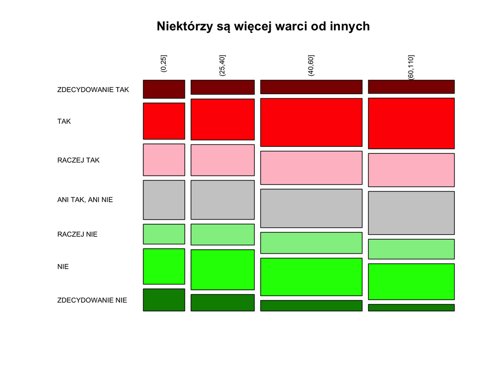

```r
mosaicplot(t(table(diagnoza$gp54_13, diagnoza$wiek2013_4)), las=2,
           col=c("red4","red1","pink","grey80","lightgreen","green1","green4"),
           main="Niektórzy są więcej warci od innych")
```

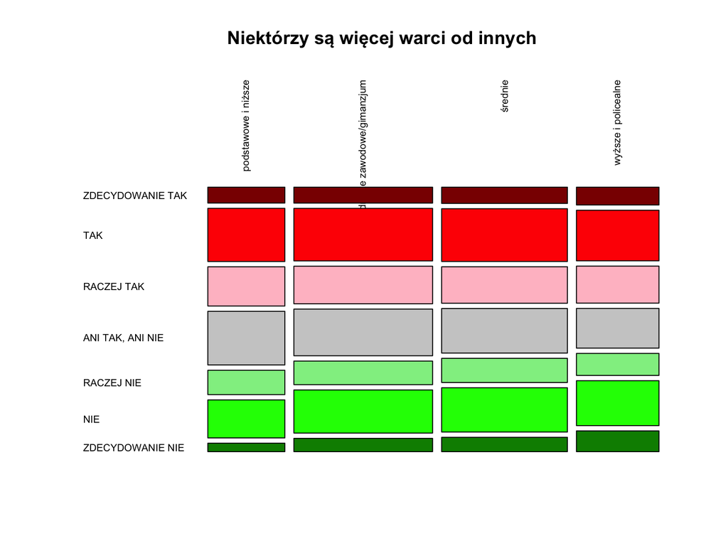

```r
mosaicplot(t(table(diagnoza$gp54_13, droplevels(diagnoza$eduk4_2013))), las=2,
           col=c("red4","red1","pink","grey80","lightgreen","green1","green4"),
           main="Niektórzy są więcej warci od innych")
```

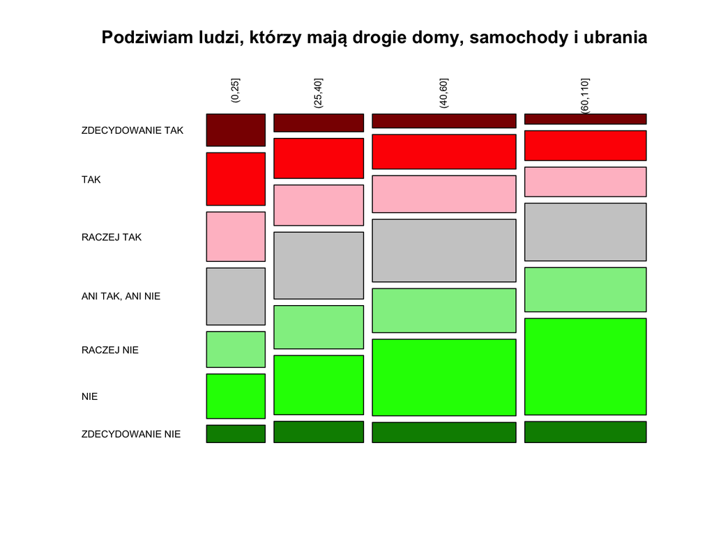

```r
mosaicplot(t(table(diagnoza$gp54_01, diagnoza$wiek2013_4)), las=2,
           col=c("red4","red1","pink","grey80","lightgreen","green1","green4"),
           main="Podziwiam ludzi, którzy mają drogie domy, samochody i ubrania")
```

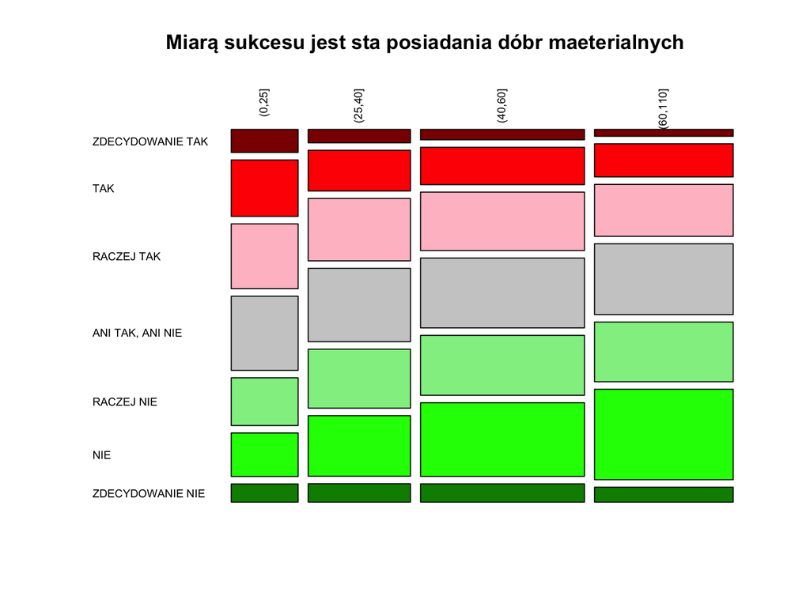

```r
mosaicplot(t(table(diagnoza$gp54_04, diagnoza$wiek2013_4)), las=2,
           col=c("red4","red1","pink","grey80","lightgreen","green1","green4"),
           main="Miarą sukcesu jest sta posiadania dóbr maeterialnych")
```

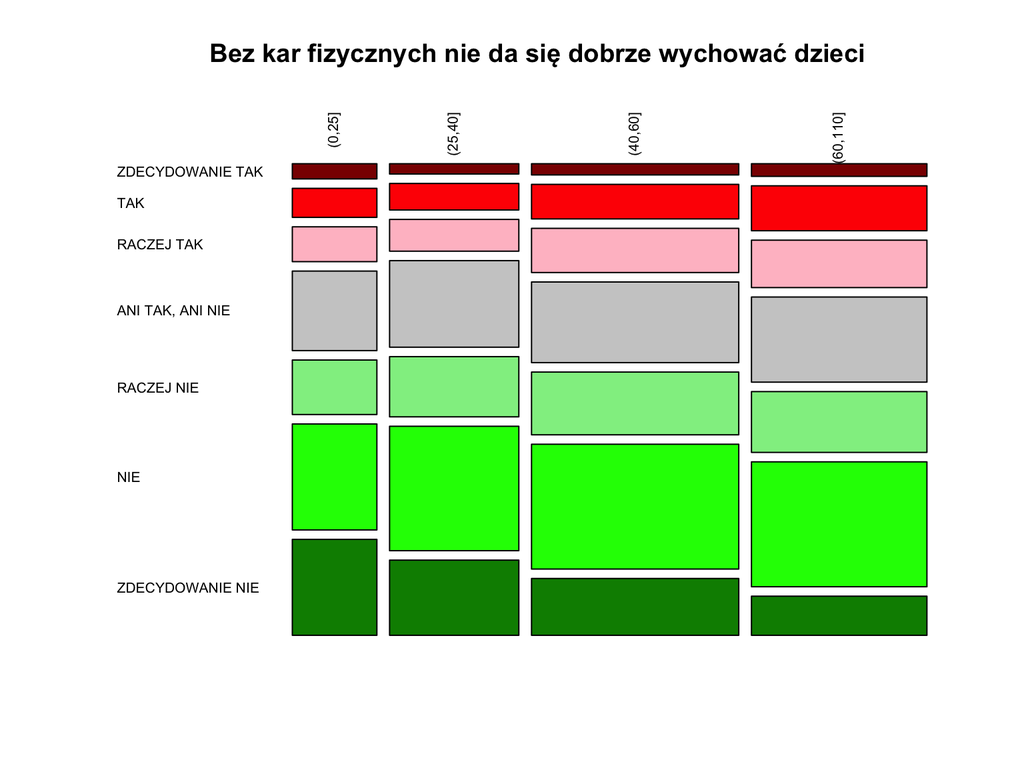

```r
mosaicplot(t(table(diagnoza$gp54_19, diagnoza$wiek2013_4)), las=2,
           col=c("red4","red1","pink","grey80","lightgreen","green1","green4"),
           main="Bez kar fizycznych nie da się dobrze wychować dzieci")
```

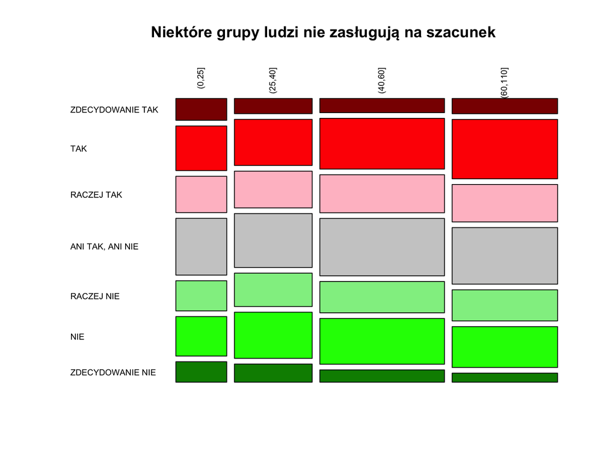

```r
mosaicplot(t(table(diagnoza$gp54_17, diagnoza$wiek2013_4)), las=2,
           col=c("red4","red1","pink","grey80","lightgreen","green1","green4"),
           main="Niektóre grupy ludzi nie zasługują na szacunek")
```

# Proporcje

Używając funkcji `prop.table()` można wyznaczyć frakcje w wierszach lub kolumnach.

```r
prop.table(edukacjaTab, 1)
```

```
##
##                                 PRZYJEMNOSCI POCZUCIE SENSU
##   podstawowe i niższe              0.3924528      0.6075472
##   zasadnicze zawodowe/gimanzjum    0.4284544      0.5715456
##   średnie                          0.3847543      0.6152457
##   wyższe i policealne              0.3362222      0.6637778
```

```r
prop.table(wiekTab, 1)
```

```
##
##            PRZYJEMNOSCI POCZUCIE SENSU
##   (0,25]      0.4904132      0.5095868
##   (25,40]     0.4191047      0.5808953
##   (40,60]     0.3767304      0.6232696
##   (60,110]    0.3402355      0.6597645
```

# Wykresy mozaikowe

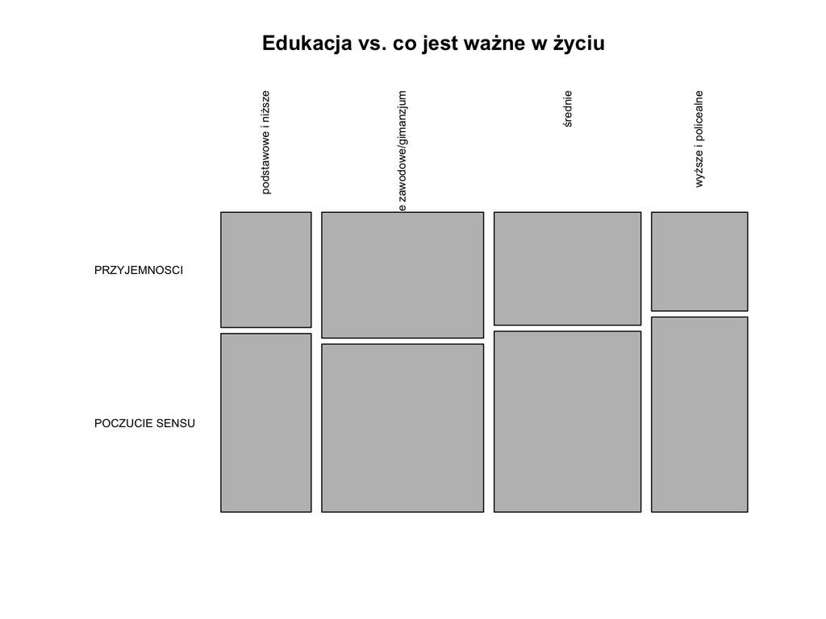

```r
mosaicplot(edukacjaTab, las=2, main="Edukacja vs. co jest ważne w życiu")
```

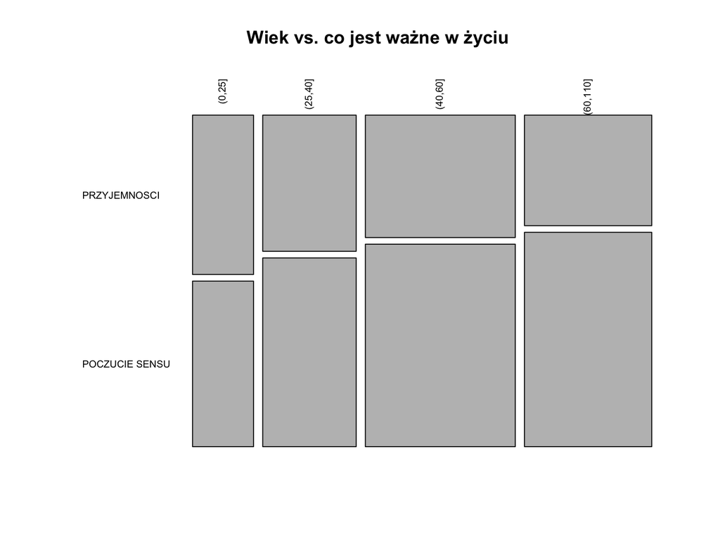

```r
mosaicplot(wiekTab, las=2, main="Wiek vs. co jest ważne w życiu")
```

# O czym jest ten odcinek

```r
table(TCGA_BRCA$czy.zyje,
      TCGA_BRCA$TP53)
prop.table(table(TCGA_BRCA$czy.zyje,
      TCGA_BRCA$TP53), 2)
# brak przerzutow dobrze rokuje
fisher.test(table(TCGA_BRCA$czy.zyje,
      TCGA_BRCA$TP53))
```

[output not shown]